# Math 1115 Project 1

Data Visualisation

510439556, 500497375, 480386102, 500199527

```r
#reading and exporting data into R
setwd('/Users/livkeayes/Desktop/UNI/sem2 21/MATH1115')
knitr::opts_chunk$set(echo = TRUE)
spotify = read.csv('spotify_dataset_cleaned (4).csv')
spotify = spotify %>% mutate(Streams = as.numeric(gsub(",", "", Streams))) # manipulate data so it correctly perceives 'Streams' as quantitative instead of qualitative
```

# 1 **Executive Summary**

The main aim of this report was to outline the relationships that make specific songs popular, and we explored musical characteristics such as tempo, genre, danceability and acousticness, and attempted to prove whether there were strong correlations between a song’s characteristics and it’s overall popularity among Spotify listeners. From what was made available in the dataset, we found that the Hip Hop, Pop, Dance Pop, and Reggaeton genres were the most popular amongst worldwide Spotify listeners, but also that there were weak correlations between a song’s tempo, danceability and acousticness with it’s popularity.

# 2 **Initial Data Analysis**

Derived from Kaggle, an online forum for data scientists and machine learning practitioners to locate and upload datasets, the Spotify Top 200 Charts (2020-2021) dataset contains various audio statistics and ratings information on over 1,500 songs. Each row corresponds to a Top 200 song and each column represents either general song information, like the artist, or quantitative ratings measuring certain audio properties, like tempo. The classification of the twenty two variables, excluding the Index, are as followed:

- Nominal categorical variables: Song name, artist, song ID, genre and chord.
- Ordinal categorical variables: Week of highest charting, release date and weeks charted.
- Quantitative variables: Highest charting position, number of times charted, streams, artist followers, popularity, danceability, energy, loudness, specchiness, acousticness, liveness, tempo, duration and valence.

However, given the limited information available pertaining to the qualifications of its creator, Sashank Pillai, this dataset is arguably not wholly valid, as anyone can upload data on Kaggle, thereby undermining its accuracy. Since this dataset has only seen 1,054 downloads as of date, compared to Kaggle.com’s over one million users, this number falls too short to lend credence to its reliability. Nevertheless, the author’s explicit acknowledgement of his use of Spotify Charts and the Spotipy python library might refute this dataset’s hindered reliability and accuracy. Yet, it is imperative to understand that the overall validity is only as strong as the algorithm itself.

In terms of limitations and issues, numerous changes had to be made to the original dataset:

- Songs that had null values for properties like streams and tempo, had to be removed, which consequently forced a restructuring of the Index value column to maintain the consecutive, ascending order.
- Songs that had no genre attached were accordingly given one upon extensive Google searches.
- The issue of crowded graph plots was overcome by reducing the multiple genres initially attached to each song with a sole, general genre.

## 2.1 Dimensions Of The Data Set

```r
# calculate the dimensions of spotify
# 23 variables and 1545 rows
dim(spotify)
```

```
## [1] 1545   23
```

## 2.2 Names Of The Variables

```r
# list the names of the variables
names(spotify)
```

```
##  [1] "Index"                     "Highest.Charting.Position"
##  [3] "Number.of.Times.Charted"   "Week.of.Highest.Charting"
##  [5] "Song.Name"                 "Streams"
##  [7] "Artist"                    "Artist.Followers"
##  [9] "Song.ID"                   "Genre"
## [11] "Release.Date"              "Weeks.Charted"
## [13] "Popularity"                "Danceability"
## [15] "Energy"                    "Loudness"
## [17] "Speechiness"               "Acousticness"
## [19] "Liveness"                  "Tempo"
## [21] "Duration..ms."             "Valence"
## [23] "Chord"
```

## 2.3 Structure Of The Data

```r
# view structure of the data
# 15 quantitative variables and 8 qualitative variables
str(spotify)
```

```
## 'data.frame':    1545 obs. of  23 variables:
##  $ Index                    : int  1 2 3 4 5 6 7 8 9 10 ...
##  $ Highest.Charting.Position: int  1 2 1 3 5 1 3 2 3 8 ...
##  $ Number.of.Times.Charted  : int  8 3 11 5 1 18 16 10 8 10 ...
##  $ Week.of.Highest.Charting : chr  "2021-07-23--2021-07-30" "2021-07-23--2021-07-30" "2021-06-25--2021-07-02" "2021-07-02--2021-07-09" ...
##  $ Song.Name                : chr  "Beggin'" "STAY (with Justin Bieber)" "good 4 u" "Bad Habits" ...
##  $ Streams                  : num  48633449 47248719 40162559 37799456 33948454 ...
##  $ Artist                   : chr  "Måneskin" "The Kid LAROI" "Olivia Rodrigo" "Ed Sheeran" ...
##  $ Artist.Followers         : int  3377762 2230022 6266514 83293380 5473565 5473565 8640063 6080597 36142273 3377762 ...
##  $ Song.ID                  : chr  "3Wrjm47oTz2sjIgck11l5e" "5HCyWlXZPP0y6Gqq8TgA20" "4ZtFanR9U6ndgddUvNcjcG" "6PQ88X9TkUIAUIZJHW2upE" ...
##  $ Genre                    : chr  "Rock" "Hip Hop" "Pop" "Pop" ...
##  $ Release.Date             : chr  "8/12/17" "9/7/21" "21/5/21" "25/6/21" ...
##  $ Weeks.Charted            : chr  "2021-07-23--2021-07-30\n2021-07-16--2021-07-23\n2021-07-09--2021-07-16\n2021-07-02--2021-07-09\n2021-06-25--202"| __truncated__ "2021-07-23--2021-07-30\n2021-07-16--2021-07-23\n2021-07-09--2021-07-16" "2021-07-23--2021-07-30\n2021-07-16--2021-07-23\n2021-07-09-…
##  $ Popularity               : int  100 99 99 98 96 97 94 95 96 95 ...
##  $ Danceability             : num  0.714 0.591 0.563 0.808 0.736 0.61 0.762 0.78 0.644 0.75 ...
##  $ Energy                   : num  0.8 0.764 0.664 0.897 0.704 0.508 0.701 0.718 0.648 0.608 ...
##  $ Loudness                 : num  -4.81 -5.48 -5.04 -3.71 -7.41 ...
##  $ Speechiness              : num  0.0504 0.0483 0.154 0.0348 0.0615 0.152 0.0286 0.0506 0.118 0.0387 ...
##  $ Acousticness             : num  0.127 0.0383 0.335 0.0469 0.0203 0.297 0.235 0.31 0.276 0.00165 ...
##  $ Liveness                 : num  0.359 0.103 0.0849 0.364 0.0501 0.384 0.123 0.0932 0.135 0.178 ...
##  $ Tempo                    : num  134 170 167 126 150 ...
##  $ Duration..ms.            : int  211560 141806 178147 231041 212000 137876 208867 199604 206710 173347 ...
##  $ Valence                  : num  0.589 0.478 0.688 0.591 0.894 0.758 0.742 0.342 0.44 0.958 ...
##  $ Chord                    : chr  "B" "C#/Db" "A" "B" ...
```

## 2.4 Viewing The Top 5 rows

```r
# view top 5 rows
head(spotify,n=5)
```

```
##   Index Highest.Charting.Position Number.of.Times.Charted
## 1     1                         1                       8
## 2     2                         2                       3
## 3     3                         1                      11
## 4     4                         3                       5
## 5     5                         5                       1
##   Week.of.Highest.Charting                         Song.Name  Streams
## 1   2021-07-23--2021-07-30                           Beggin' 48633449
## 2   2021-07-23--2021-07-30         STAY (with Justin Bieber) 47248719
## 3   2021-06-25--2021-07-02                          good 4 u 40162559
## 4   2021-07-02--2021-07-09                        Bad Habits 37799456
## 5   2021-07-23--2021-07-30 INDUSTRY BABY (feat. Jack Harlow) 33948454
##           Artist Artist.Followers                Song.ID   Genre Release.Date
## 1       Måneskin          3377762 3Wrjm47oTz2sjIgck11l5e    Rock      8/12/17
## 2  The Kid LAROI          2230022 5HCyWlXZPP0y6Gqq8TgA20 Hip Hop       9/7/21
```

[output cut: 21 more lines]

## 2.5 Viewing The Bottom 5 rows

```r
# view top 5 rows
tail(spotify,n=5)
```

```
##      Index Highest.Charting.Position Number.of.Times.Charted
## 1541  1541                       195                       1
## 1542  1542                       196                       1
## 1543  1543                       197                       1
## 1544  1544                       198                       1
## 1545  1545                       199                       1
##      Week.of.Highest.Charting                          Song.Name Streams
## 1541   2019-12-27--2020-01-03                          New Rules 4630675
## 1542   2019-12-27--2020-01-03                 Cheirosa - Ao Vivo 4623030
## 1543   2019-12-27--2020-01-03          Havana (feat. Young Thug) 4620876
## 1544   2019-12-27--2020-01-03         Surtada - Remix Brega Funk 4607385
## 1545   2019-12-27--2020-01-03 Lover (Remix) [feat. Shawn Mendes] 4595450
##                             Artist Artist.Followers                Song.ID
## 1541                      Dua Lipa         27167675 2ekn2ttSfGqwhhate0LSR0
## 1542                Jorge & Mateus         15019109 2PWjKmjyTZeDpmOUa3a5da
```

[output cut: 21 more lines]

# 3 **Research Question 1 - 510439556**

Does the popularity rate (amount of streams) of songs correlate to their tempo?

## 3.1 Domain Knowledge

In order to properly investigate and decide on my research question, I had to do a range of background research to expand on my knowledge on the relationship between music popularity and tempo. In a recent study, neurologist Jacob Joliji, aimed to figure out what musical aspects of a song made it so appealing. He developed a formula, called the Feel Good Index, which considered a song’s tempo along with other elements such as its key in relation to its popularity. He found that the higher the Feel Good Index, the higher the popularity of the song, indicating that a quick tempo can impact it’s streaming rates. He came to the conclusion that songs with 150 beats per minute were the most listened to (Kim, 2015). Furthermore, Researchers from California State Polytechnic University looked into Spotify data from 2017 and 2018 to see what made songs trend and found that some songs of low tempo were popular as they were ‘an easy, enjoyable listen’, but also found that the majority of the preferred songs were of a fast tempo (Al-Beitawi, Salehan & Zhang, 2020).

# 4 **Graphical Summary**

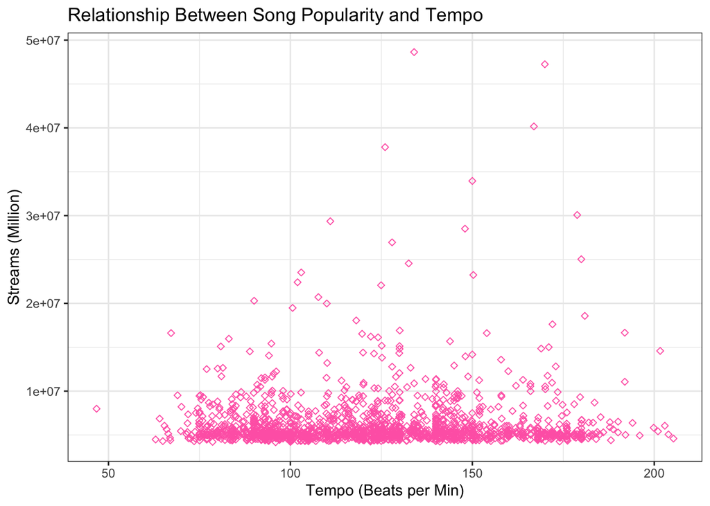

```r
# Constructing Scatter Plot
spotify %>%
ggplot(aes(Tempo, Streams))+geom_point(color="hotpink", size=1.5, shape=23) + # identifying variables to graph as well as the colour, shape and size of the plots
  labs(title="Relationship Between Song Popularity and Tempo",
       x="Tempo (Beats per Min)", y = "Streams (Million)") + theme_bw() # creating title and labeling x and y axis
```

The results of this graph seem to be hidden by the sheer scale of this data set. Despite a few incredibly popular songs, most have under 10 million streams so i am going to reduce my data to those in order to find a clearer linear trend.

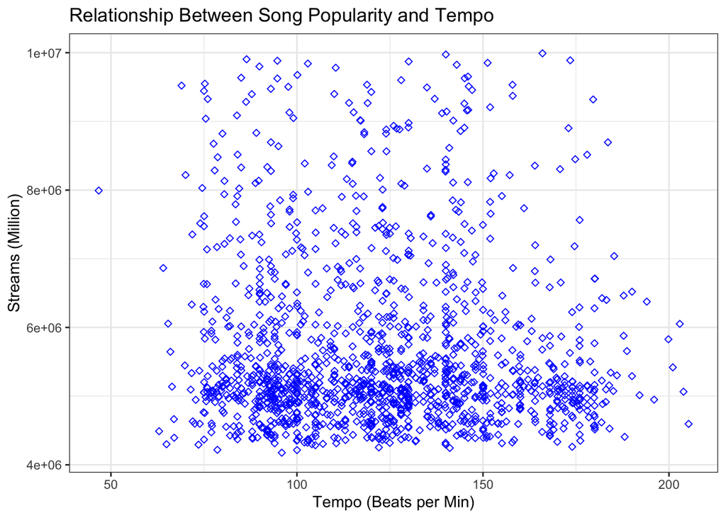

```r
# Constructing Refined Scatter Plot
spotify %>%
  filter(Streams<10000000) %>% # filtering data so it is more refined and easier to analyse
ggplot(aes(Tempo, Streams))+geom_point(color="blue", size=1.5, shape=23) +
  labs(title="Relationship Between Song Popularity and Tempo",
       x="Tempo (Beats per Min)", y = "Streams (Million)") + theme_bw()
```

```r
# Finding Correlation Coefficient
Tempo = spotify$Tempo # identifying variables
Streams = spotify$Streams
cor(Streams, Tempo)
```

```
## [1] 0.05345843
```

Upon viewing this selected data, as well as the weak, positive correlation coefficient, it indicates that there is no strong relationship between a song’s tempo and its popularity. Interestingly, this result contradicts the ideas of the domain knowledge research.

# 5 **Conclusion**

Ultimately, after analyzing the data, there was no significant correlation between a song’s popularity and its tempo.

# 6 Bibliography

- Al-Beitawi, Z., Salehan, M. & Zhang, S. (2020). What Makes a Song Trend? Cluster Analysis of Musical Attributes for Spotify Top Trending Songs. Journal of Marketing Development and Competitiveness, 14(3), 79–91. https://doi.org/10.33423/jmdc.v14i3.3065
- Kim, M. (2015). The Secret Math Behind Feel Good Music. The Washington Post. Retrieved from:https://www.washingtonpost.com/news/to-your-health/wp/2015/10/30/the-mathematical-formula-behind-feel-good-songs/

# 7 **Research Question 2 - 480386102**

Assess whether there exists a relationship between acousticness and popularity; that is, are today’s popular songs more or less acoustic?

## 7.1 Domain Knowledge

Given the ubiquitous nature of technology across all walks of life, it would be foolish to assume that today’s popular music scene would be the exception, and apparently so, as just the opposite is true (Dredge, 2013). Mirroring technology’s integration into greater society at large, popular music as of date and most recently has been influenced by the rise in *Electronic Dance Music*, think David Guetta, Calvin Harris and Skrillex. This has seen an influx in electro beats and a consequent divergence away from more acoustic sounds (Feinstein and Ramsay, 2012). Hence, drawing from these empirical findings, it is the well-informed **prediction** that we should see a negative correlation between acousticness and popularity in this dataset.

# 8 **Discussion of Results and Analysis**:

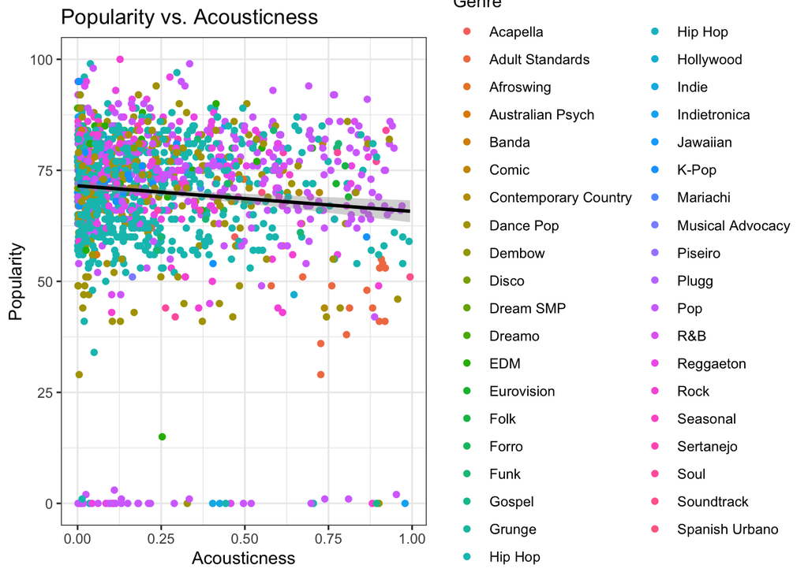

```r
options(warn=-1)
g = ggplot(spotify,aes(Acousticness,Popularity,colour=Genre)) +
  geom_point() + #scatter plot
  xlab("Acousticness") + #naming x-axis as Acousticness
  ylab("Popularity") + #naming y-axis as Popularity
  ggtitle("Popularity vs. Acousticness") + #setting title
  stat_smooth(method = "lm",col = "black") + #constructing linear regression line
  theme_bw() #adding theme

g
```

Visually demonstrated by the negatively sloped linear regression line above, the **correlation** between *Acousticness* and *Popularity* found below of **-0.09** seemingly validates the hypothesis; how popular music today has diverted away from orchestral instruments like acoustic guitars and natural drum kits. However, its close proximity to zero denotes a **weak correlation**, somewhat meaning that there is almost no linear relationship between the two variables. However, by performing Pearson’s correlation test and finding the **p-value** to be **0.0003**, we accept the alternative hypothesis at the 5% significance level and reject the null hypothesis that there is no linear relationship between *Acousticness* and *Popularity*.

```r
cor(spotify$Acousticness, spotify$Popularity)
```

```
## [1] -0.09124461
```

```r
test <- cor.test(spotify$Acousticness, spotify$Popularity)
test
```

```
##
##  Pearson's product-moment correlation
##
## data:  spotify$Acousticness and spotify$Popularity
## t = -3.5992, df = 1543, p-value = 0.0003293
## alternative hypothesis: true correlation is not equal to 0
## 95 percent confidence interval:
##  -0.14047608 -0.04156304
## sample estimates:
##         cor
## -0.09124461
```

# 9 Bibliography

- Dredge, S. (2013, Nov 26). Pop music is louder, less acoustic and more energetic than in the 1950s. *The Guardian: Australian Edition*.
- Feinstein, D. & Ramsay, C. (2012). The Rise of EDM. *Music Business Journal: Berklee College of Music*.http://www.thembj.org/2012/10/the-rise-of-edm/

# 10 **Research Question 3 - 500199527**

Does a correlation exist between a song’s popularity and its danceability?

## 10.1 Domain Knowledge

When we listen to the music, it always want to dance with music and we define this feeling called Danceability. Moreover It is interesting that the music with high danceability seem to be more popular now. Morover,Recent survey shows most of successful and famous songs’s authors are prefer characterize their songs by higher ‘danceability’ (Interiano Myra, Kazemi Kamyar, Wang Lijia, Yang Jienian, Yu Zhaoxia and Komarova Natalia L. 2018). To find out do it exist the correction between the songs’ Danceability and popularity. We analyse the data from spotify

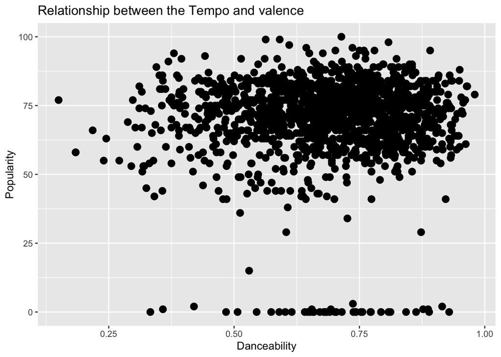

```r
ggplot(data = spotify, mapping = aes(x = Danceability, y = Popularity)) + geom_point(size = 3)+labs(title="Relationship between the Tempo and valence", x = "Danceability", y = "Popularity")
```

First we use ggplot to drew a scatter plot of Danceability and Popularity. According to the scatter plot, the distribution of data is random and hard to find the linear correlation.

```r
cor(spotify$Danceability,spotify$Popularity)
```

```
## [1] 0.02843469
```

Using cor() function to caculate the correlation score which is 0.02843469. The correlation score is much smaller than 0.5. Hence it means that there is no correlation between danceability and populatrity

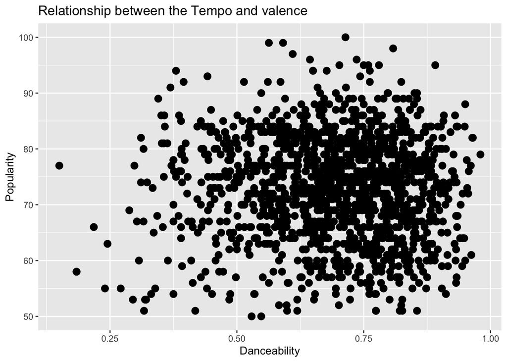

```r
High_Popularity_Songs1 = filter(spotify,spotify$Popularity>=50)
ggplot(data = High_Popularity_Songs1, mapping = aes(x = Danceability, y = Popularity)) +geom_point(size = 3)+labs(title="Relationship between the Tempo and valence", x = "Danceability", y = "Popularity")
```

Although there is no a high correlation but it is easy to find some interesting relationships. When we filter discrete values and focus on the data with more than half of popularity, we find the most of popular songs have the high danceability, especially in the range of danceability from 0.7 to 0.8. It also find to songs’s author like to make their music danceable.

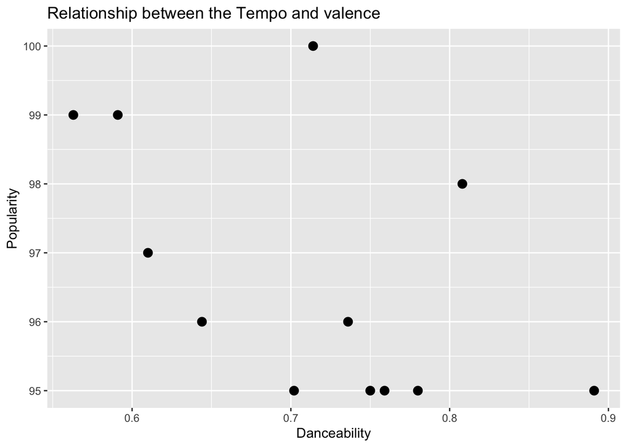

```r
High_Popularity_Songs2 = filter(spotify,spotify$Popularity>=95)
ggplot(data = High_Popularity_Songs2, mapping = aes(x = Danceability, y = Popularity)) + geom_point(size = 3)+labs(title="Relationship between the Tempo and valence", x = "Danceability", y = "Popularity")
```

This situation will be more clear when we concentrate on the most popular songs which popularity is more than 95. The graphy show that the top 12 songs are all with more 0.5 popularity.The half of them is in the range of 0.7 to 0.8.

# 11 **Conclusion**

Popular music is always with high danceability, but it not exists high correlation between danceability and popularity. However , it is interesting that the most popular songs all have a high danceability

# 12 Bibliography

- Interiano Myra, Kazemi Kamyar, Wang Lijia, Yang Jienian, Yu Zhaoxia and Komarova Natalia L. 2018Musical trends and predictability of success in contemporary songs in and out of the top chartsR. Soc. open sci.5171274171274 http://doi.org/10.1098/rsos.171274

# 13 **Research Question 4 - 500497375**

What genre of music do listeners on Spotify enjoy listening to the most?

Another topic we wanted to explore with this Spotify data set was finding out which genre of music listeners from all over the world were listening to the most. We wanted to have a look at what type of music the world is listening to. Exploring this data helps us understand what genres of music people are interested in the most, which helps us identify trends that will help us understand what the music industry is looking to do in the future. The most effective way to map out this was to illustrate a bar graph, with the x axis being the amount of Streams compared to the y axis, which is the genre of music.

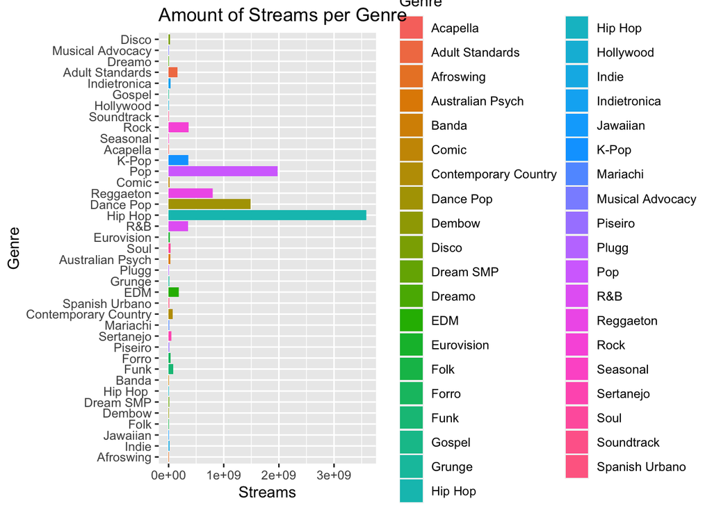

```r
spotify %>%
  ggplot(aes(Streams, reorder(Genre, Streams), fill = Genre)) +
  geom_bar(stat = "identity") +
  xlab("Streams") +
  ylab("Genre") +
  ggtitle("Amount of Streams per Genre") +
  theme(plot.title = element_text(hjust = 0))
```

Observation: Hip Hop is the most listened to genre of music. Pop, Dance Pop and Reggaeton music come behind Hip Hop.

While the report supports the fact that Hip Hop is the most popular genre of music, the genre that surprisingly came in 2nd place was Rock music. This could be because this report only explicitly covers the United States instead of the whole world, which can result in different tastes in music. Pop music came in 3rd place, while Dance/EDM music came in 6th, with Reggaeton not even appearing within the top 11.

# 14 Bibliography

- Distribution of streamed music consumption in the United States in 2020, by genre. (2021, July 20). Retrieved from https://www.statista.com/statistics/475667/streamed-music-consumption-genre-usa/